# Métodos Cuantitativos

**Clase 07 - Distribuciones continuas**  
Unidad I: Estadística y Probabilidades con Python

## Breve repaso

- Hasta el momento, hemos estudiado algunas **distribuciones discretas** y hemos utilizado la **función de masa de probabilidad (PMF)** y la **función de distribución acumulativa (CDF)** para calcular probabilidades puntuales o rangos específicos.
- A continuación, estudiaremos las **distribuciones continuas**, que nos permiten modelar variables capaces de tomar un número infinito de valores dentro de un intervalo determinado.

## Distribuciones continuas

- En el estudio de las distribuciones continuas, la **función de densidad de probabilidad (PDF)** reemplaza a la **PMF** como la herramienta principal para describir la probabilidad relativa de que una variable aleatoria tome un valor específico.
- Aunque, en el sentido estricto, la probabilidad de que una variable continua tome un valor puntual exacto es cero, la **PDF nos permite determinar la densidad de probabilidad en cualquier punto del dominio de la variable**, ofreciendo una forma de entender cómo se distribuyen los valores a lo largo de un continuo.

## Digresión

- ¿Por qué la probabilidad de que una variable continua tome un valor puntual exacto es cero?
- En las **distribuciones discretas**, tratamos con variables que pueden tomar **valores contables**.
- Por ejemplo, el número de autos que pasan por un peaje en una hora puede ser 0, 1, 2, 3, etc., pero no puede ser 2.5.
- La probabilidad de cada uno de estos valores contables puede ser descrita por la función de masa de probabilidad (PMF), y sumando estas probabilidades individuales podemos obtener la probabilidad total.

## Digresión

- En contraste, las **distribuciones continuas** se aplican a variables que pueden tomar **cualquier valor dentro de un rango continuo**.
- Por ejemplo, el tiempo que tarda un auto en pasar de un punto A a un punto B puede ser cualquier número real dentro de un rango, como 10.5 segundos, 10.55 segundos, 10.555 segundos, etc.
- Dado que hay infinitos números dentro de cualquier rango, la probabilidad de que la variable tome un valor específico exacto dentro de ese rango es infinitesimal, esencialmente cero.

## Distribuciones continuas

- Seguiremos empleando la **función de distribución acumulativa (CDF)**, la cual es igualmente fundamental en el contexto de las distribuciones continuas.
- La CDF nos indica la probabilidad de que una variable aleatoria tome un **valor menor o igual a un cierto límite**, proporcionando una forma directa de **calcular rangos de probabilidad**.

## ¿Qué veremos hoy?

- **Distribución normal**
- Normal estándar
- Uniforme continua
- Exponencial y gamma
- Teorema del Límite Central

## Distribución Normal

- Una de las distribuciones continuas más importantes es la **distribución normal**, también conocida como distribución *gaussiana*.
- Esta distribución es ampliamente utilizada debido a su aparición frecuente en la naturaleza y su robustez en una variedad de aplicaciones.
- La distribución normal se caracteriza por su forma de campana simétrica y está determinada por dos parámetros: la **media ($\mu$)** y **la desviación estándar ($\sigma$)**. Estos parámetros controlan la ubicación y la dispersión de los datos alrededor de la media.

## Distribución Normal

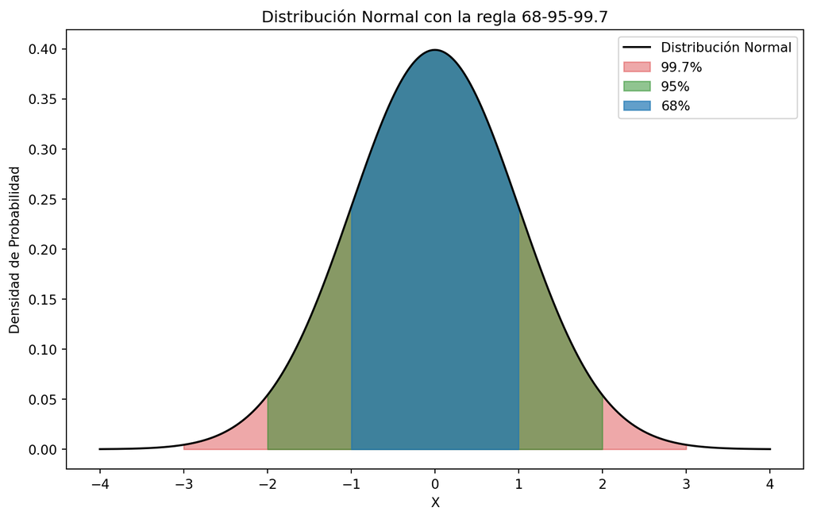

## Distribución Normal PDF y CDF

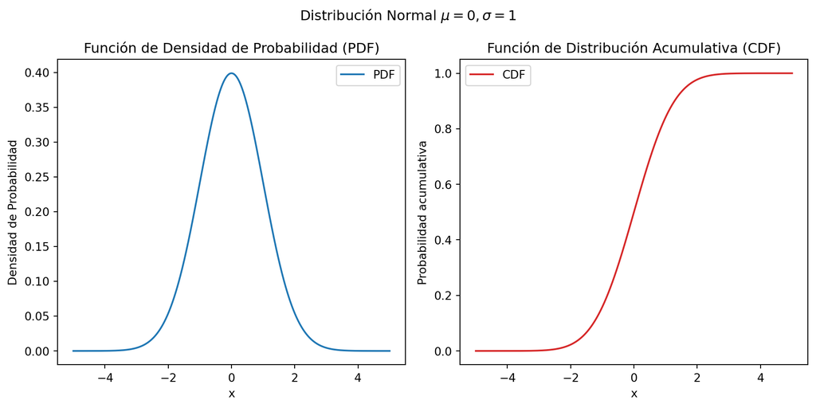

## Distribución Normal

- Supongamos que realizamos una prueba a 100 alumnos, en la cual el puntaje máximo es 100.
- Al analizar los resultados de las pruebas, observamos que las calificaciones se **distribuyen normalmente** con una **media ($\mu$) de 75 puntos** y **una desviación estándar ($\sigma$) de 10 puntos**.
- Nos gustaría estimar **la probabilidad de que un estudiante elegido al azar haya obtenido una calificación dentro de un rango específico**, así como **la probabilidad de obtener una calificación superior a un cierto valor**.

## Distribución Normal

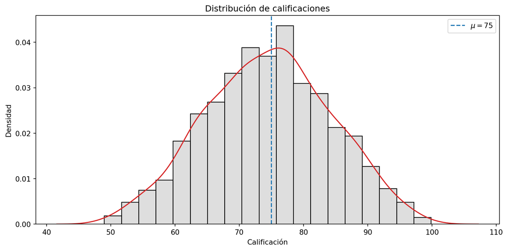

## Distribución Normal

- Para resolver este problema, podemos usar la **distribución normal** para modelar las calificaciones de los alumnos.
- La variable aleatoria $X$ representa la calificación de un alumno.
- La media $\mu$ es de 75 puntos y la desviación estándar $\sigma$ es de 10 puntos.
- Con estos datos, podemos calcular, por ejemplo:
  - La probabilidad de que un alumno obtenga una calificación entre 65 y 85 puntos.
  - La probabilidad de que un alumno obtenga una calificación superior a 90 puntos.
  - La densidad de la distribución en 75 puntos y cómo interpretarla correctamente.

## Distribución Normal en Python

La probabilidad de que un alumno obtenga una calificación entre 65 y 85 puntos:

```python
from scipy.stats import norm

mu = 75
sigma = 10

# calculamos la probabilidad de obtener una calificación de 85 o menos
prob_85 = norm.cdf(85, mu, sigma)

# calculamos la probabilidad de obtener una calificación de 65 o menos
prob_65 = norm.cdf(65, mu, sigma)

# calculamos la probabilidad de obtener una calificación entre 65 y 85
prob_65_85 = prob_85 - prob_65

# reportamos la probabilidad
print(f"{prob_65_85} o {round(prob_65_85 * 100, 2)}%")
```

```
0.6826894921370859 o 68.27%
```

## Distribución Normal en Python

La probabilidad de que un alumno obtenga una calificación superior a 90 puntos:

```python
from scipy.stats import norm

mu = 75
sigma = 10

# calculamos la probabilidad de obtener una calificación superior a 90
prob_gt_90 = norm.sf(90, mu, sigma)

# reportamos la probabilidad
print(f"{prob_gt_90} o {round(prob_gt_90 * 100, 2)}%")
```

```
0.06680720126885806 o 6.68%
```

```python
# calculamos la probabilidad de obtener una calificación de 90 o menos
prob_90 = norm.cdf(90, mu, sigma)
prob_gt_90 = 1 - prob_90

# reportamos la probabilidad
print(f"{prob_gt_90} o {round(prob_gt_90 * 100, 2)}%")
```

```
0.06680720126885809 o 6.68%
```

## Distribución Normal en Python

En una distribución continua, la probabilidad de que un alumno obtenga exactamente 75 puntos es 0. Sin embargo, sí podemos calcular la **densidad** de la distribución en 75 puntos.

```python
from scipy.stats import norm

mu = 75
sigma = 10

# en una distribución continua, P(X = 75) = 0; aquí calculamos la densidad en 75
densidad_75 = norm.pdf(75, mu, sigma)

# reportamos la densidad
print(f"Densidad en 75 puntos: {densidad_75}")
```

```
Densidad en 75 puntos: 0.03989422804014327
```

## ¿Qué veremos hoy?

- Distribución normal
- **Normal estándar**
- Uniforme continua
- Exponencial y gamma
- Teorema del Límite Central

## Distribución Normal Estándar

- La distribución normal estándar es un caso específico de la distribución normal, una de las distribuciones continuas más fundamentales y ampliamente utilizadas en estadística y teoría de probabilidades.
- La principal característica de esta distribución es que tiene una **media ($\mu$) = 0** y la **desviación estándar ($\sigma$) = 1**.
- Esto significa que hemos “estandarizado” la distribución normal general para tener una media de 0 y una desviación estándar de 1.

## Distribución Normal Estándar

La función de densidad de probabilidad de la distribución normal estándar es:

$$f(z) = \frac{1}{\sqrt{2\pi}}e^{-\frac{1}{2}z^{2}}$$

donde $z$ es una variable **estandarizada** que se obtiene a partir de la ecuación:

$$z = \frac{x-\mu}{\sigma}$$

Este proceso de estandarización **transforma cualquier distribución normal en la distribución normal estándar**. La variable $z$ representa el número de desviaciones estándar que un valor $x$ está por encima o por debajo de la media $\mu$.

## Distribución Normal Estándar

- La normalización permite comparar puntuaciones o datos de diferentes distribuciones normales, facilitando la interpretación de estadísticas en una variedad de campos.
- Para entender su importancia, veamos el siguiente ejemplo:
  - Supongamos que cierto banco quiere crear 4 segmentos de clientes o *clusterizar* (concepto utilizado en machine learning para separar o categorizar a un grupo de datos de acuerdo a algunas características en común), para realizar esta tarea, el banco dispone la información de la **edad y los ingresos de un grupo de 1000 clientes**.

## Distribución Normal Estándar

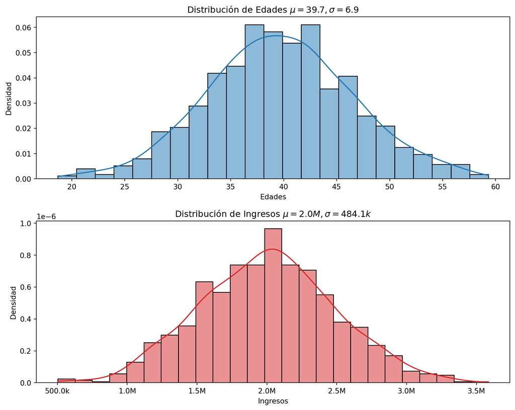

## Distribución Normal Estándar

Al aplicar el algoritmo *k-medias* a los datos, obtenemos los siguientes resultados: (El algoritmo k-medias agrupa datos en *k* grupos asignando iterativamente puntos al centroide más cercano y actualizando los centroides hasta converger).

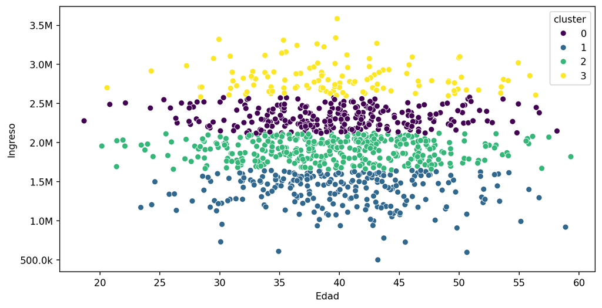

## Distribución Normal Estándar

Recordemos la fórmula:
$$z = \frac{x-\mu}{\sigma}$$

La podemos aplicar de la siguiente manera:

```python
data["zscore_edad"] = (
  (data["Edad"] - data["Edad"].mean()) / data["Edad"].std()
)

data["zscore_ingreso"] = (
  (data["Ingreso"] - data["Ingreso"].mean()) / data["Ingreso"].std()
)

print(data.head())
```

```
        Edad  Ingreso  zscore_edad  zscore_ingreso
0  52.348366  2277981     1.832162        0.559902
1  42.801100  2446236     0.451040        0.907305
2  46.851166  1788842     1.036928       -0.450043
3  55.686252  2052357     2.315025        0.094047
4  53.072906  2114026     1.936974        0.221377
```

## Distribución Normal Estándar

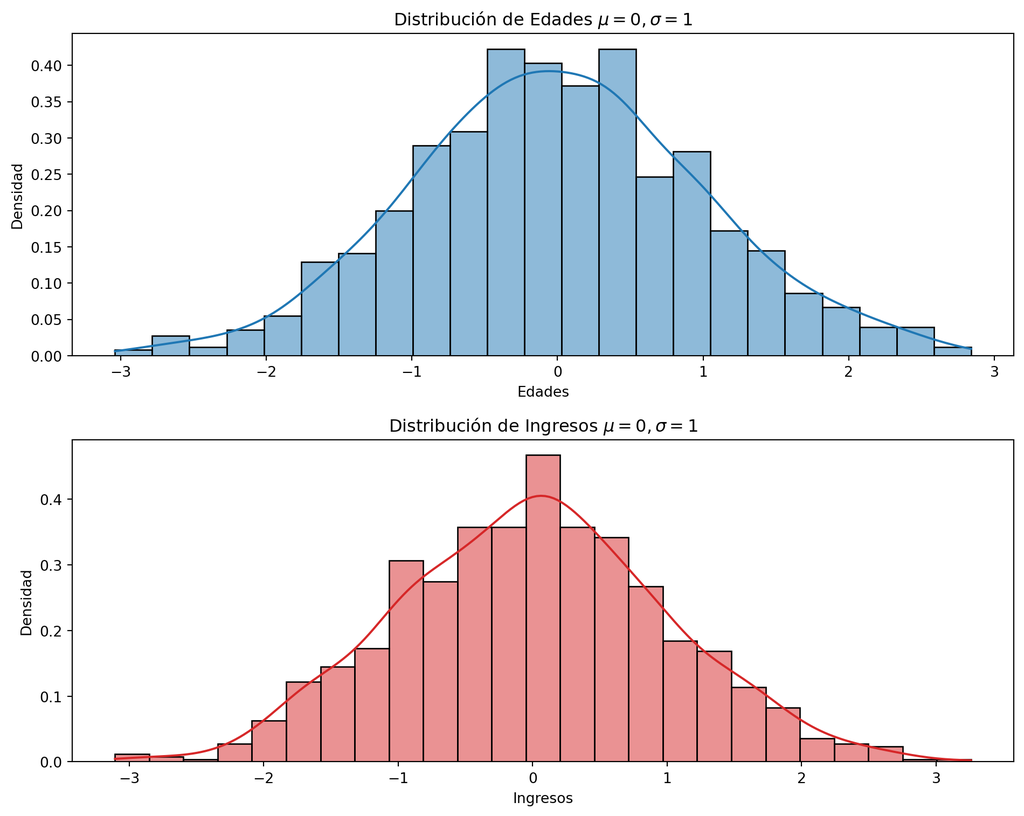

## Distribución Normal Estándar

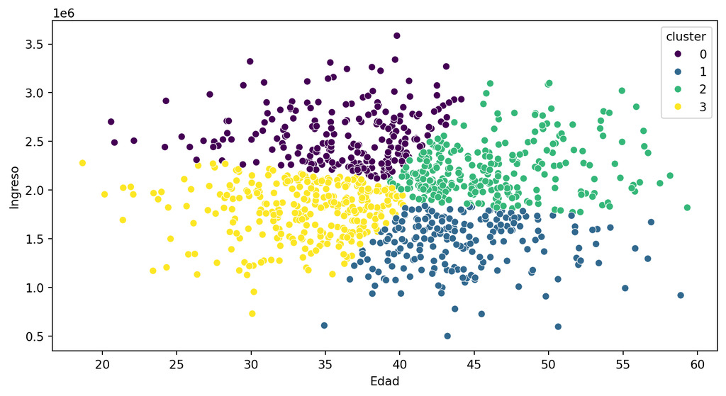

- Normalizar las variables antes de aplicar el algoritmo k-medias asegura que cada una tenga el mismo peso durante la formación de los *clusters*.
- Si las variables tienen diferentes rangos, la que tenga valores más grandes dominará la medida de distancia, lo que podría resultar en una segmentación sesgada.
- Al normalizar, se ayuda a que la formación de los segmentos sea más homogénea y refleje mejor las similitudes en términos de la estructura de los datos en lugar de su escala.

## ¿Qué veremos hoy?

- Distribución normal
- Normal estándar
- **Uniforme continua**
- Exponencial y gamma
- Teorema del Límite Central

## Distribución Uniforme Continua

- La distribución uniforme continua es una distribución continua que asigna la misma **densidad** a todos los valores dentro de un intervalo específico definido por los límites $a$ y $b$.
- Es útil para modelar situaciones donde cualquier valor real dentro de un rango es igualmente plausible, como tiempos de llegada, mediciones continuas o simulaciones de fenómenos naturales o procesos industriales.

## Distribución Uniforme Continua

- Imaginemos que una máquina genera un valor real al azar entre 1 y 100. Nos interesa calcular la probabilidad de que el valor generado caiga dentro de ciertos rangos.
- Para analizar esta situación, podemos utilizar la **distribución uniforme continua**.
  - La variable aleatoria $X$ representa el valor real generado por la máquina.
  - Los parámetros $a$ y $b$ definen los límites de la distribución, que en este caso son 1 y 100, respectivamente.
- Dado que es una distribución uniforme continua, todos los valores del intervalo tienen la misma densidad. Por ejemplo, podemos calcular:
  - La probabilidad de que el valor generado sea menor que 50.
  - La probabilidad de que el valor esté entre 25 y 75.

## Distribución Uniforme en Python

```python
from scipy.stats import uniform

# definir los límites de la distribución
a = 1  # límite inferior
b = 100  # límite superior

# crear una distribución uniforme continua entre a y b
distribucion_uniforme = uniform(a, b-a)

# calcular probabilidades
# probabilidad de que el valor generado sea menor que 50
prob_lt_50 = distribucion_uniforme.cdf(50)

# probabilidad de que el valor esté entre 25 y 75
prob_entre_25_75 = distribucion_uniforme.cdf(75) - distribucion_uniforme.cdf(25)

print(f"Probabilidad de que el valor sea menor que 50: {prob_lt_50}")
print(f"Probabilidad de que el valor esté entre 25 y 75: {prob_entre_25_75}")
```

```
Probabilidad de que el valor sea menor que 50: 0.494949494949495
Probabilidad de que el valor esté entre 25 y 75: 0.5050505050505051
```

## Distribución Uniforme PDF y CDF

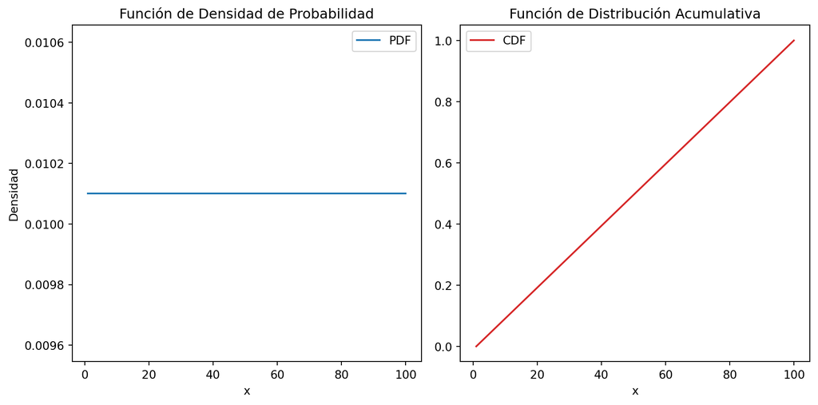

## ¿Qué veremos hoy?

- Distribución normal
- Normal estándar
- Uniforme continua
- **Exponencial y gamma**
- Teorema del Límite Central

## Distribución Exponencial

- La distribución Exponencial es una distribución de probabilidad continua que se utiliza comúnmente para modelar el tiempo entre eventos en un proceso de **Poisson**, es decir, cuando los eventos ocurren de manera continua e independiente a una tasa constante.
- Es particularmente útil para modelar tiempos de espera, como la duración entre fallos de equipos, tiempos de respuesta en sistemas de servicio, y otros eventos que siguen un patrón de tiempo continuo.

## Distribución Exponencial

- Consideremos el caso de una compañía de telecomunicaciones que desea estudiar el tiempo entre fallas de su red para mejorar el servicio. A partir de registros previos, se determina que el tiempo promedio entre fallos es de 30 días.
- Para analizar y prever estos tiempos entre fallos, podemos emplear la **distribución Exponencial**.
  - La variable aleatoria $X$ representa el tiempo entre fallos consecutivos en la red.
  - El parámetro $\lambda$, la tasa de fallos, se calcula como el inverso del tiempo medio entre fallos, lo que en este caso es $\frac{1}{30}$.
- Por ejemplo, podemos calcular:
  - La probabilidad de que el siguiente fallo ocurra en menos de 10 días.
  - La probabilidad de que el siguiente fallo ocurra entre 20 y 30 días.
  - La densidad de la distribución en 25 días y cómo interpretarla correctamente.
  - La probabilidad de que pasen más de 50 días antes del siguiente fallo.

## Distribución Exponencial PDF y CDF

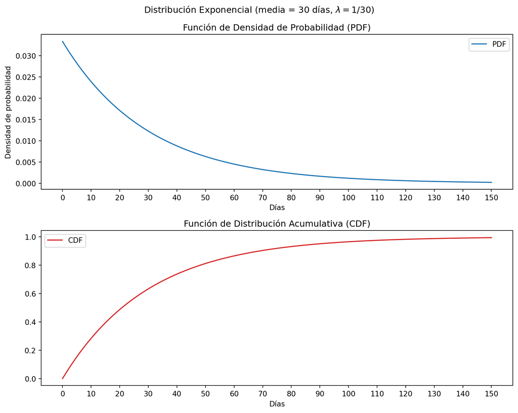

## Distribución Exponencial en Python

La probabilidad de que el siguiente fallo ocurra en menos de 10 días:

```python
from scipy.stats import expon

# parámetro de la distribución exponencial
lambda_inv = 30  # tiempo medio entre fallos

# probabilidad de que el siguiente fallo ocurra en menos de 10 días
prob_menos_10 = expon.cdf(10, scale=lambda_inv)

print(f"Prob. que el siguiente fallo ocurra en menos de 10 días: {prob_menos_10}")
```

```
Prob. que el siguiente fallo ocurra en menos de 10 días: 0.28346868942621073
```

## Distribución Exponencial en Python

La probabilidad de que el siguiente fallo ocurra entre 20 y 30 días:

```python
from scipy.stats import expon

# parámetro de la distribución exponencial
lambda_inv = 30  # tiempo medio entre fallos

# probabilidad de que el siguiente fallo ocurra entre 20 y 30 días
prob_menos_30 = expon.cdf(30, scale=lambda_inv)
prob_menos_20 = expon.cdf(20, scale=lambda_inv)
prob_bt_20_30 = prob_menos_30 - prob_menos_20

print(f"Prob. de que el siguiente fallo ocurra entre 20 y 30 días: {prob_bt_20_30}")
```

```
Prob. de que el siguiente fallo ocurra entre 20 y 30 días: 0.14553767786114968
```

## Distribución Exponencial en Python

En una distribución continua, la probabilidad de que el siguiente fallo ocurra exactamente a 25 días es 0. Sin embargo, sí podemos calcular la **densidad** en 25 días.

```python
from scipy.stats import expon

# parámetro de la distribución exponencial
lambda_inv = 30  # tiempo medio entre fallos

# en una distribución continua, P(X = 25) = 0; aquí calculamos la densidad en 25 días
densidad_25 = expon.pdf(25, scale=lambda_inv)

print(f"Densidad en 25 días: {densidad_25}")
```

```
Densidad en 25 días: 0.01448660695023594
```

## Distribución Exponencial en Python

La probabilidad de que pasen más de 50 días antes del siguiente fallo:

```python
from scipy.stats import expon

# parámetro de la distribución exponencial
lambda_inv = 30  # tiempo medio entre fallos

# probabilidad de que pasen más de 50 días antes del siguiente fallo
prob_gt_50 = expon.sf(50, scale=lambda_inv)

print(f"Prob. de que pasen más de 50 días antes del siguiente fallo: {prob_gt_50}")
```

```
Prob. de que pasen más de 50 días antes del siguiente fallo: 0.18887560283756183
```

## Distribución Gamma

- La distribución Gamma es una distribución continua que se utiliza para **modelar tiempos de espera hasta que ocurren $k$ eventos en un proceso con tiempos entre eventos siguiendo una distribución exponencial**.
- Parámetros de la Distribución Gamma:
  - Parámetro de Forma ($k$): El parámetro de forma, influye en la forma de la distribución de la variable aleatoria.
  - Parámetro de Escala ($\theta$): El parámetro determina la escala de la distribución y está relacionado con el tiempo promedio que se requiere para completar cada fase del proyecto.
- Esta distribución es especialmente útil para modelar la duración de eventos en una amplia gama de aplicaciones, como la vida útil de productos, el tiempo de servicio al cliente, etc.

## Distribución Gamma

- Imaginemos que estamos evaluando el tiempo total que toman los desarrollos de software en ser completados en cierta empresa.
- Basados en datos históricos, sabemos que, en promedio, un proyecto se completa en 120 días, pero la variabilidad es alta debido a la naturaleza compleja de estos proyectos.
- Para modelar el tiempo de finalización de estos proyectos, podemos utilizar la **distribución Gamma**.

## Distribución Gamma

- Siguiendo el ejemplo:
  - La variable aleatoria $X$ representa el tiempo total en días para completar un desarrollo.
- El parámetro de forma ($k$) en este contexto se puede interpretar como el número de fases o etapas críticas que deben completarse para finalizar un proyecto.
  - El parámetro de escala ($\theta$) está relacionado con el tiempo promedio que se requiere para completar cada fase del proyecto.
- Por ejemplo, si consideramos un parámetro de forma $k=9$ y un parámetro de escala $\theta=13.33$ (dando una media de $120$ días), podemos calcular:
  - La probabilidad de que un proyecto se complete en menos de 100 días.
  - La probabilidad de que un proyecto tome más de 150 días para completarse.

## Distribución Gamma en Python

```python
from scipy.stats import gamma

# parámetros de la distribución Gamma
k = 9  # parámetro de forma
media_completar_proyecto = 120
theta = (media_completar_proyecto/k)  # parámetro de escala

# crear una distribución Gamma
distribucion_gamma = gamma(a=k, scale=theta)

# calcular probabilidades
# probabilidad de que un proyecto se complete en menos de 100 días
prob_lt_100 = distribucion_gamma.cdf(100)

# probabilidad de que un proyecto tome más de 150 días para completarse
prob_gt_150 = distribucion_gamma.sf(150)

print(f"Prob. que un proyecto se complete en menos de 100 días: {prob_lt_100}")
print(f"Prob. que un proyecto tome más de 150 días para completarse: {prob_gt_150}")
```

```
Prob. que un proyecto se complete en menos de 100 días: 0.3380328808585169
Prob. que un proyecto tome más de 150 días para completarse: 0.21054094346059704
```

## Distribución Gamma PDF y CDF

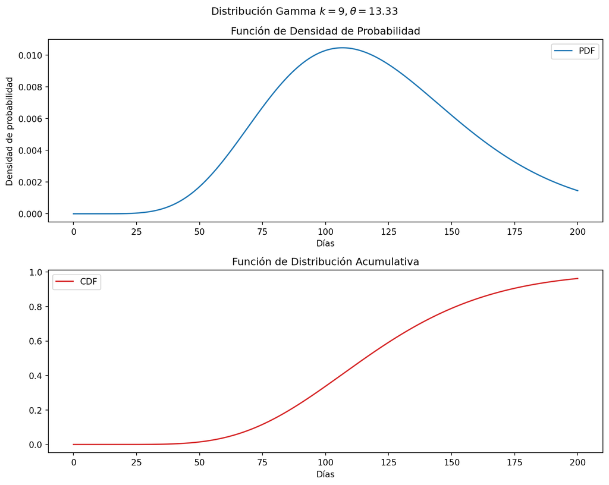

## Distribuciones Discretas y Continuas

| Característica | Distribución Discreta | Distribución Continua |
| --- | --- | --- |
| Valores posibles | Contables (finitos o infinitos) | Incontables (infinitos) |
| Ejemplos | Número de caras al lanzar una moneda, número de hijos en una familia | Altura de una persona, peso de un objeto |
| Representación gráfica | Función de masa de probabilidad (PMF) | Función de densidad de probabilidad (PDF) |
| Cálculo de probabilidad | Sumando probabilidades en puntos específicos | Integrando la PDF en un intervalo |

## Análisis de medias de distribuciones

- Consideremos una variable aleatoria $X$ proveniente de una distribución arbitraria; por ejemplo, una distribución Binomial y realicemos el siguiente experimento:
  - Establecemos $X \sim Binomial(10, 0.5)$.
  - Generamos 2000 muestras, cada una de tamaño 40, lo que implica realizar 2000 repeticiones de 40 experimentos binomiales, cada uno con 10 ensayos y una probabilidad de éxito de 0.5.

```python
from scipy.stats import binom

# parámetros
numero_muestras = 2000
tamano_muestra = 40

# crear distribución
distribucion_binom = binom(n=10, p=0.5)

# crear variable aleatoria
va = distribucion_binom.rvs((numero_muestras, tamano_muestra))

print(va)
```

```
[[5 5 3 ... 7 6 5]
 [5 6 7 ... 4 6 4]
 [6 5 5 ... 5 3 6]
 ...
 [6 6 5 ... 7 5 5]
 [6 3 5 ... 6 4 7]
 [6 5 6 ... 4 2 3]]
```

## Análisis de medias de distribuciones

- Calculemos las medias de cada una de las 2000 repeticiones, obteniendo así un conjunto de 2000 medias:

```python
medias = np.mean(va, axis=1)

print(len(medias))
print(medias)
```

```
2000
[5.2   5.1   5.3   ... 5.225 5.05  4.925]
```

- A continuación, visualicemos estas medias en un histograma para entender su distribución:

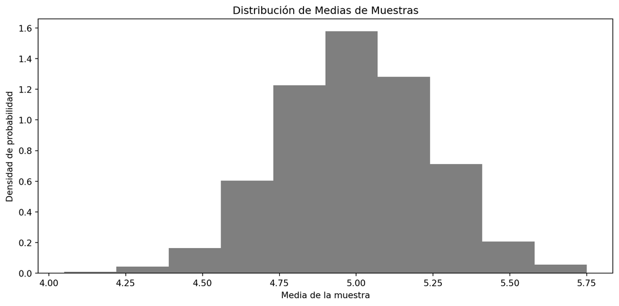

## ¿Qué veremos hoy?

- Distribución normal
- Normal estándar
- Uniforme continua
- Exponencial y gamma
- **Teorema del Límite Central**

## Teorema del Límite Central

- El comportamiento anteriormente observado constituye un pilar central de la estadística y se denomina **Teorema del Límite Central (TLC)**.
- Este teorema es crucial porque nos ayuda a entender por qué la distribución normal es tan prevalente en estadística y por qué funciona bien para aproximaciones y análisis estadísticos, incluso cuando la distribución subyacente de los datos no es normal.

## Teorema del Límite Central

- El Teorema del Límite Central establece que, para una muestra suficientemente grande de observaciones independientes e idénticamente distribuidas, la distribución de la media muestral tiende a una distribución normal, independientemente de la forma de la distribución original.
- Este teorema tiene algunas condiciones y suposiciones:
  - Las observaciones deben ser independientes.
  - Las observaciones deben provenir de una distribución con varianza finita.
  - El tamaño de la muestra debe ser suficientemente grande (usualmente se considera un tamaño de muestra de 30 o más como suficiente).

## Teorema del Límite Central

- El TLC es fundamental en estadística porque justifica la utilización de la inferencia estadística, que incluye la construcción de intervalos de confianza y la realización de pruebas de hipótesis.
- Gracias al TLC, podemos usar métodos estadísticos basados en la distribución normal para modelar fenómenos y tomar decisiones informadas en situaciones donde los datos reales no siguen necesariamente esta distribución.

## Teorema del Límite Central

[video not shown]

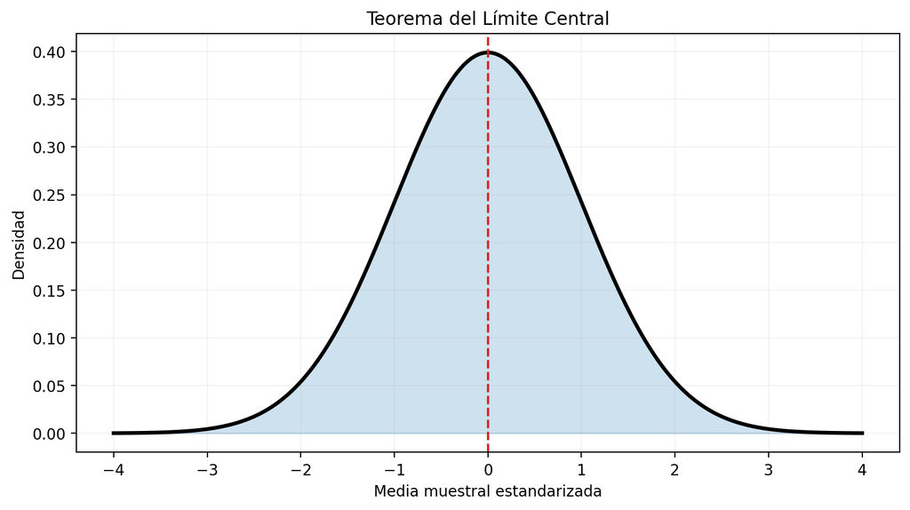